# HW6

Heath Blackmon

2/22/2018

As we have mentioned in class the distribution of offspring produced by males and females differ in many species and this can be a sign of sexual selection. Download the provided zebra finch dataset.

## Problem 1

Make a plot that visualizes the raw data. Calculate the 95% confidence interval for the number of offspring that both males and females produce using the approach from section 11.7. Discuss whether the data meet the assumptions of this method.

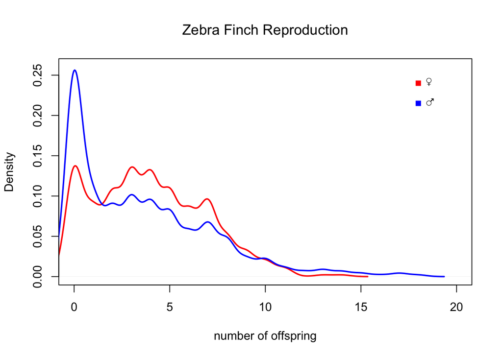

```r
finch <- read.csv("zebra.fench.csv")
plot(density(finch$fem.prod, bw=.45), col="red", lwd=2,
     main="Zebra Finch Reproduction",
     xlab="number of offspring",
     ylim=c(0,.26), xlim=c(0,20))
lines(density(finch$male.prod, bw=.45), col="blue", lwd=2)
points(x=18,y=.24, pch=15, col="red")
points(x=18,y=.215, pch=15, col="blue")
text(x=18,y=.24, labels="\\VE",vfont=c("sans serif","bold"), pos=4)
text(x=18,y=.215, labels="\\MA",vfont=c("sans serif","bold"), pos=4)
```

CI calculation:

```r
fem.res <- t.test(finch$fem.prod)$conf.int
mal.res <- t.test(finch$male.prod)$conf.int
```

The female 95% CI is 3.713, 4.251. The male 95% CI is 3.258, 3.937. The data does not appear to be a sample from a normal distribution and this violates this approach to calculating the confidence interval.

## Problem 2

Try transforming this dataset to make it more normal. Plot a comparison of the raw and transformed data. Write a sentences describing your interpretation of your result.

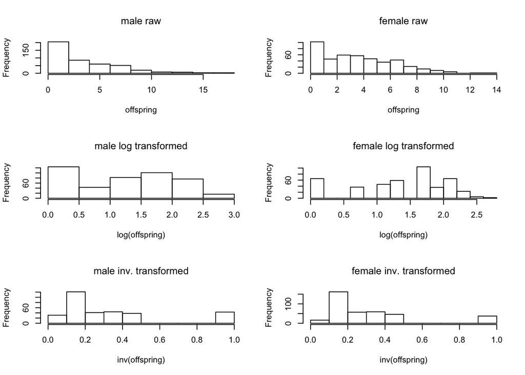

```r
lg.mal <- log(finch$male.prod+1)
lg.fem <- log(finch$fem.prod+1)
inv.mal <- 1/finch$male.prod
inv.fem <- 1/finch$fem.prod
par(mfcol=c(3,2))
hist(finch$male.prod, main="male raw",xlab="offspring")
hist(lg.mal, main="male log transformed",xlab="log(offspring)")
hist(inv.mal, main="male inv. transformed",xlab="inv(offspring)")
hist(finch$fem.prod, main="female raw",xlab="offspring")
hist(lg.fem, main="female log transformed",xlab="log(offspring)")
hist(inv.fem, main="female inv. transformed",xlab="inv(offspring)")
```

Neither the log nor inverse transformations deal adequatly with the non normal nature of the data.

## Problem 3

Determine whether males have a lower mean offspring number than females.

Because the data is not normally distributed and transformations fail to fix this we will use a permutation test to answer this question.

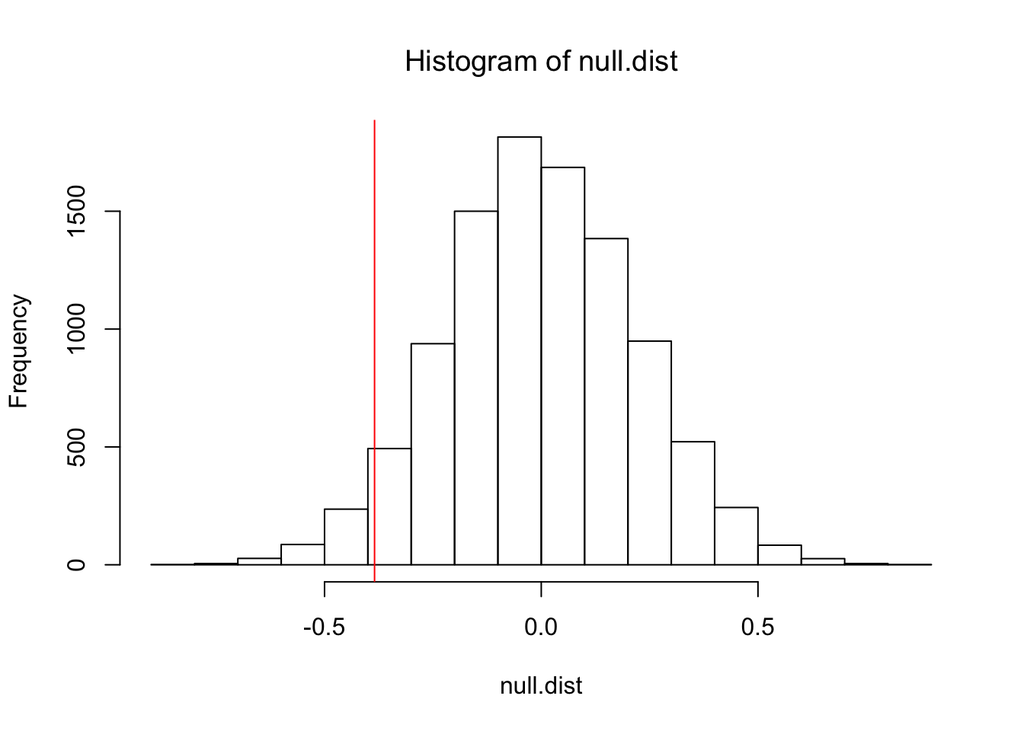

```r
null.dist <- vector()
pop <- c(finch$fem.prod,finch$male.prod)
for(i in 1:10000){
  shuffled.data <- sample(pop)
  new.mal <- shuffled.data[1:442]
  new.fem <- shuffled.data[443:884]
  null.dist[i] <- mean(new.mal)-mean(new.fem)
}
obs <- mean(finch$male.prod)-mean(finch$fem.prod)
hist(null.dist)
abline(v=obs, col="red")
```

```r
pval <- sum(null.dist<=obs)/length(null.dist)
t.test(finch$fem.prod,finch$male.prod)
```

```
##
##  Welch Two Sample t-test
##
## data:  finch$fem.prod and finch$male.prod
## t = 1.7449, df = 837.67, p-value = 0.08136
## alternative hypothesis: true difference in means is not equal to 0
## 95 percent confidence interval:
##  -0.0480225  0.8172533
## sample estimates:
## mean of x mean of y
##  3.981900  3.597285
```

We get a pvalue of 0.042 so we determine that the mean number of offspring is different

## Problem 4

Determine whether males and females have significantly different variance. Compare your result to Levine’s test.

Because the data is not normally distributed and transformations fail to fix this we will use a permutation test to answer this question.

```r
library(car)
```

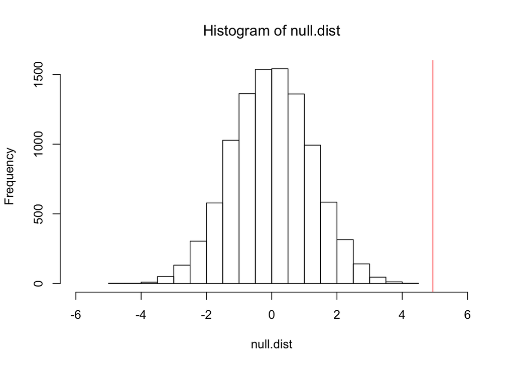

```r
null.dist <- vector()
pop <- c(finch$fem.prod,finch$male.prod)
for(i in 1:10000){
  shuffled.data <- sample(pop)
  new.mal <- shuffled.data[1:442]
  new.fem <- shuffled.data[443:884]
  null.dist[i] <- var(new.mal) - var(new.fem)
}
obs <- var(finch$male.prod) - var(finch$fem.prod)
hist(null.dist, xlim=c(-6,6))
abline(v=obs, col="red")
```

```r
pval.perm <- sum(null.dist>=obs)/length(null.dist)
x <- c(finch$fem.prod,finch$male.prod)
y <- c(rep("F", 442), rep("M", 442))
z <- data.frame(x,y)
pval.levines <- leveneTest(y=z$x, group=z$y)[1,3]
```

We calculate a p-value of 0 using a permutation test, and we calculate a p-value of 2.810^{-4} using Levine’s test. Suggesting that the variance is indeed differnt in males and females.